# Assignment 6 - Open data and API

Author

Meghan Stewart

# 1 Goal of this assignment

The goal of this assignment is for you to leverage open data APIs in R related to your field of study.

In specific, you will be asked to:  
- Identify an open data base related to your field of study  
- Retrieve data from it into R (bonus points if through an API instead of manually)  
- Create questions one could ask of these data, and answer them with wrangling, tables, and plots

# 2 Instructions

1. Identify an open data in relation to your field of study. The minimum requirements for these data are:
- It needs to be open (i.e., public data that anyone can access)
- It needs to report some variable of importance across time (e.g., multiple days, months, years, etc.) and/or space (e.g., cities, counties, states, countries, etc.), ideally both.
2. Bring these data into R, bonus points if you use an API for that (instead of manually)
3. Create 6 questions you can ask of these data. Of these questions:
- At least 4 should require some wrangling to be answered (like a group_by and summarise, etc.)
- At least 3 should be answered with a graph

```r
library(jsonlite)
library(httr)
library(ggplot2)
library(tidyverse)
library(dplyr)
library(purrr)
```

# 3 Questions

## 3.1 1. What is your field of study?

**Food Science & Technology**

## 3.2 2. What is the open data you identified? Please explain it in terms of its source (website, which agency reported it), variable of importance, temporal and spatial characteristics, and anything else relevant for someone outside of your field of study to fully understand what it represents.

*The open data source identified is from the FDA and is a collection of reported adverse events from food products in the U.S. The particular dataset pulled includes variables of importance such as product involved, product industry and affiliated codes, adverse symptoms reported, and overall outcomes based on severity. The temporal characteristics include report year with spacial characteristics summarized for the entire U.S. The product’s role details whether it is generally suspect in the adverse events or if contamination was involved.See link to datasite here : https://open.fda.gov/apis/download-api-fields/*

## 3.3 3. The FDA’s adverse event site reports adverse events for different industries. Summarize into a dataset adverse events for a **sample of 100 reports** by year from 2004-2023 for the Nut product industry. Perform some wrangling of needed data columns including important information such as adverse events, product name, industry name and code, product’s role in adverse event, and observed reactions.

*Hint: The industry code is 23 and you will need to use the function “GET()” to pull the right API dataset.*

```r
events <- GET("https://api.fda.gov/food/event.json?search=date_started:[20040101+TO+20230101]")
```

```r
nuts <- GET("https://api.fda.gov/food/event.json?search=products.industry_code:23&limit=100")

summary(nuts)
```

```
            Length Class       Mode
url             1  -none-      character
status_code     1  -none-      numeric
headers        20  insensitive list
all_headers     1  -none-      list
cookies         7  data.frame  list
content     64781  -none-      raw
date            1  POSIXct     numeric
times           6  -none-      numeric
request         7  request     list
handle          1  curl_handle externalptr
```

```r
new_nuts <- fromJSON(rawToChar(nuts$content))

#head(new_nuts)
```

```r
nutella <- new_nuts[["results"]] %>%
  select(date_created, outcomes, reactions, products)

#head(nutella)
```

```r
nutella1 <- nutella %>%
  unnest_longer(outcomes, values_to = "outcomes") %>%
  unnest_longer(reactions, values_to = "reactions")


#head(nutella1)
```

```r
nutella2 <- nutella1 %>%
  unnest_wider(products, names_sep = "_" )

head(nutella2)
```

```
# A tibble: 6 × 7
  date_created outcomes        reactions       products_role products_name_brand
  <chr>        <chr>           <chr>             <list<chr>>         <list<chr>>
1 20090331     Hospitalization ATRIOVENTRICUL…           [1]                 [1]
2 20090331     Hospitalization Adverse reacti…           [1]                 [1]
3 20090331     Hospitalization FEELING OF BOD…           [1]                 [1]
4 20090331     Hospitalization INFLUENZA LIKE…           [1]                 [1]
5 20090331     Hospitalization NAUSEA                    [1]                 [1]
6 20090331     Hospitalization VOMITING                  [1]                 [1]
# ℹ 2 more variables: products_industry_code <list<chr>>,
#   products_industry_name <list<chr>>
```

```r
nutella_year <- nutella2 %>%
  separate(date_created, into = c("year", "month_day"), sep = 4)
#nutella_year

nutella_year2 <- nutella_year %>%
  separate(month_day, into = c("month", "day"), sep = 2)

glimpse(nutella_year2)
```

```
Rows: 389
Columns: 9
$ year                   <chr> "2009", "2009", "2009", "2009", "2009", "2009",…
$ month                  <chr> "03", "03", "03", "03", "03", "03", "03", "03",…
$ day                    <chr> "31", "31", "31", "31", "31", "31", "31", "31",…
$ outcomes               <chr> "Hospitalization", "Hospitalization", "Hospital…
$ reactions              <chr> "ATRIOVENTRICULAR BLOCK", "Adverse reaction", "…
$ products_role          <list<chr>> "SUSPECT", "SUSPECT", "SUSPECT", "SUSPECT…
$ products_name_brand    <list<chr>> "SUNKIST PISTACHIOS IN SHELL", "SUNKIST P…
$ products_industry_code <list<chr>> "23", "23", "23", "23", "23", "23", "23",…
$ products_industry_name <list<chr>> "Nuts/Edible Seed", "Nuts/Edible Seed", "…
```

```r
year_nutsum <- nutella_year2 %>%
  group_by(year) %>%
count(year, name = "total_events")

year_nutsum
```

```
# A tibble: 18 × 2
# Groups:   year [18]
   year  total_events
   <chr>        <int>
 1 2004             2
 2 2006             3
 3 2007            28
 4 2008             1
 5 2009            92
 6 2010            14
 7 2011            18
 8 2012             7
 9 2013             4
10 2014            21
11 2015             7
12 2016            19
13 2017             2
14 2018             2
15 2022           125
16 2023            20
17 2024            15
18 2025             9
```

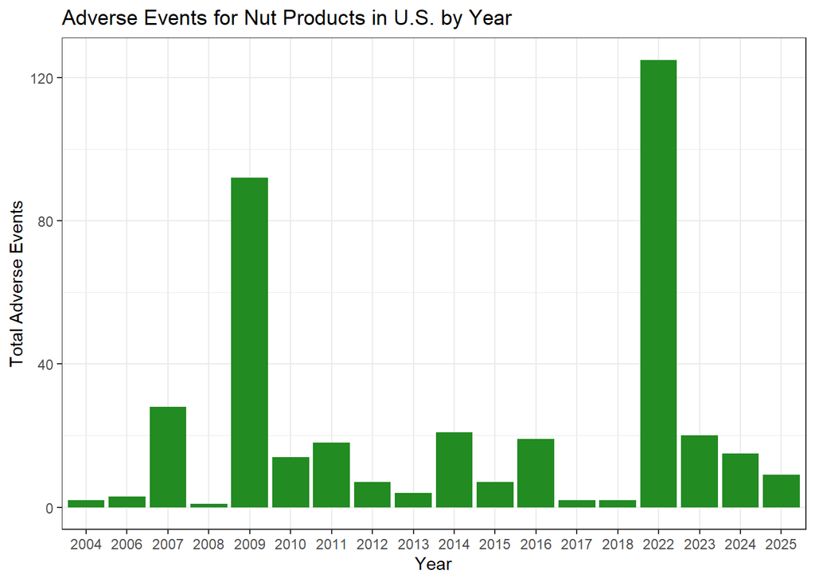

```r
ggplot(year_nutsum, aes(x = factor(year), y = total_events)) +
  geom_col(fill = "forestgreen") +
  labs(title = "Adverse Events for Nut Products in U.S. by Year",
       x = "Year",
       y = "Total Adverse Events"
       ) +
  theme_bw()
```

## 3.5 5. What products were involved in each year’s total adverse events? Summarize results in a bar chart for each year showing total adverse events for each product involved in that given year. Show just one plot for 2010 for total adverse events .

*Hint: use a mapping function to change the plot name by year for data used in it.*

```r
product_events <- nutella_year2 %>%
  count(year, products_name_brand, name = "Events_by_Product")

product_events$products_name_brand[[1]]
```

```
[1] "TRADER JOE'S ORGANIC PEANUT BUTTER"
```

```r
length(product_events$products_name_brand[[1]])
```

```
[1] 1
```

```r
#so trying to run below chunk for mapping didn't work with this column being the character type it is so I have to convert it below. It's a list so maybe I can apply a functoin that works over a list like lapply or sapply : use paste() for joining list elements to create one name for each row and then adding a "_" to join names separated originally in the list.

product_events <- product_events %>%
  mutate(products_name_brand = sapply(products_name_brand, function(x) paste(x, collapse = "_" )))

product_events
```

```
# A tibble: 84 × 3
   year  products_name_brand                                   Events_by_Product
   <chr> <chr>                                                             <int>
 1 2004  TRADER JOE'S ORGANIC PEANUT BUTTER                                    1
 2 2004  CASTELLA VANILLA FLAVOR (ARTIFICIAL)_ALMONDS_COCONUTS                 1
 3 2006  ADAM'S 100% NATURAL CREAMY PEANUT BUTTER                              1
 4 2006  JIF SMOOTH PEANUT BUTTER                                              2
 5 2007  PETER PAN CREAMY PEANUT BUTTER                                       10
 6 2007  PETER PAN PETER PAN CRUNCHY PEANUT BUTTER                            14
 7 2007  PETER PAN REDUCED FAT CREAMY                                          4
 8 2008  HARRIS TEETER NATURAL ORGANIC RAW SUNFLOWER SEED                      1
 9 2009  SUNKIST PISTACHIOS IN SHELL                                          24
10 2009  PETER PAN CRUNCHY PEANUT BUTTER_CRACKER                               3
# ℹ 74 more rows
```

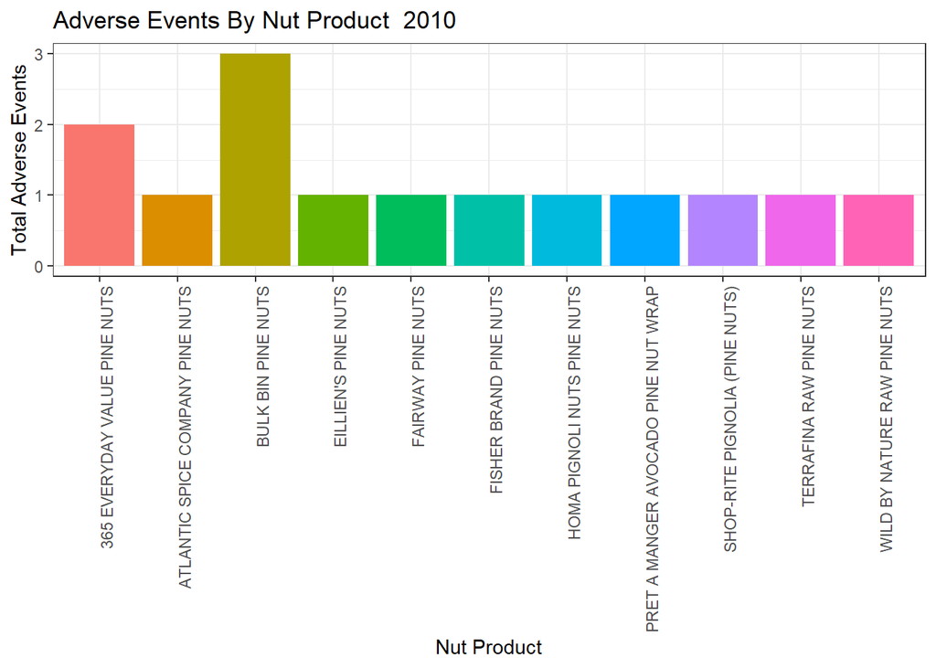

```r
year_of_nutella <- sort(unique(product_events$year))


nut_plots <- map(year_of_nutella, ~ {nutty_year <- product_events %>% filter(year == .x)

ggplot(nutty_year, aes(x = products_name_brand, y = Events_by_Product, fill = products_name_brand)) +
  geom_col() +
  labs(title = paste("Adverse Events By Nut Product ", .x),
       x = "Nut Product",
       y = "Total Adverse Events") +
  theme_bw() +
  #adding next line because when I previewed plots you the x-axis labels were overlapping too much to read:
  theme(axis.text.x = element_text(angle = 90, hjust = 1),
        legend.position = "none")

})

names(nut_plots) <- year_of_nutella


nut_plots$`2010`
```

```r
#omg it actually worked
```

## 3.6 6. For each nut product associated with adverse events, summarize in a bar plot the total number of outcomes for each outcome type reported. What products resulted in hospitalization?

*Hint: you will need to set up y-axis to have total number of outcome reports, with bars for each product on x-axis by outcome type.*

```r
product_outcome <- nutella_year2 %>%
  mutate(products_name_brand = sapply(products_name_brand, function(x) paste(x, collapse = "_" ))) %>%
  count(products_name_brand, outcomes, name = "Net_outcomes")

head(product_outcome)
```

```
# A tibble: 6 × 3
  products_name_brand                      outcomes              Net_outcomes
  <chr>                                    <chr>                        <int>
1 365 EVERYDAY VALUE PINE NUTS             Other Outcome                    2
2 ADAM'S 100% NATURAL CREAMY PEANUT BUTTER Other Outcome                    1
3 AMPORT FOODS PINE NUTS                   Other Outcome                    4
4 AMPORT FOODS PINE NUTS RAW               Other Outcome                    2
5 ARCHER FARMS MIXED NUTS                  Hospitalization                  6
6 ARCHER FARMS MIXED NUTS                  Required Intervention            6
```

```r
#adding below mod because of issues rendering plots

#will use split() function here instead of filter() like previously to split dataframe based on grouping variable "outcome". Then I'll try to use mapping like I did before.

outcome_plots <- split(product_outcome, product_outcome$outcomes)
#head(outcome_plots)
```

[figure not shown]

```r
# note for meghan: .x in function() below is a placeholder for each data frame that was split by outcome in previous chunk.

nut_plot3 <- map(
  outcome_plots,
  function(.x) {nut_outcome <- unique(.x$outcomes)
  ggplot(.x, aes(x = products_name_brand,
                y = Net_outcomes)) +
    geom_col(fill = "purple") +
    #had to add bottom part because titles kept being cut off in test plots
   # coord_flip(clip = "off") +
    #above didn't work so I just turned the flip off.
    labs( title = paste("Products Associated with Certain Adverse Outcomes:", nut_outcome),
          x = "Product Name",
          y = "Total Outcome Events") +
    theme_bw() +
    theme(
      axis.text.y = element_text(size = 5),
      axis.text.x = element_text(angle = 76, hjust = 1),
      plot.margin = margin(t = 80, r = 80, b = 20, l = 20))

  }
)

nut_plot3$Hospitalization
```

## 3.7 7. Show using a plot the highest to lowest years for “Visited a healthcare provider” outcomes for nut products from the 2004-2023 dataset.

```r
provider_1 <- nutella_year2 %>%
  filter(outcomes == "Visited a Health Care Provider") %>%
 count(year, name = "Provider_visits") %>%
  arrange(desc(Provider_visits))

provider_1
```

```
# A tibble: 8 × 2
  year  Provider_visits
  <chr>           <int>
1 2009               17
2 2016               11
3 2007                7
4 2014                7
5 2023                5
6 2022                3
7 2011                1
8 2015                1
```

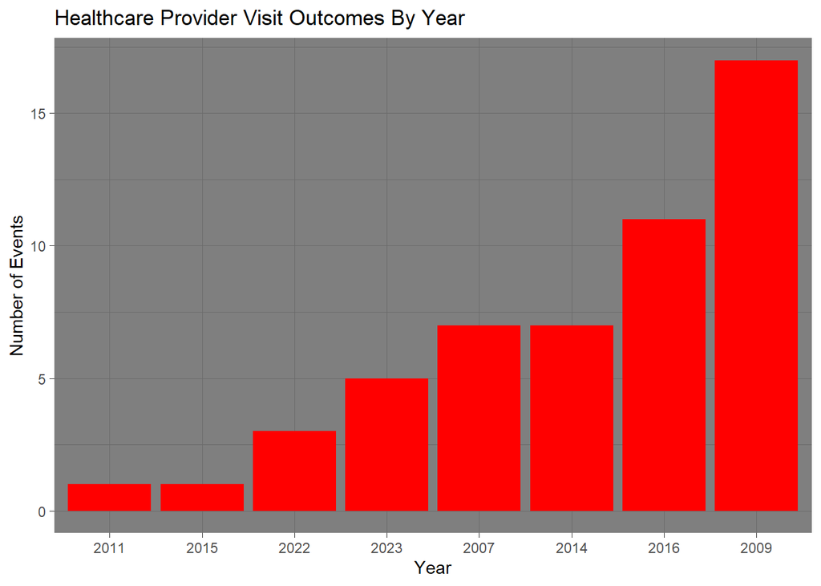

```r
ggplot(provider_1, aes(x = reorder(as.factor(year), Provider_visits), y = Provider_visits)) +
  geom_col(fill = "red") +
  labs(
    title = "Healthcare Provider Visit Outcomes By Year",
    x = "Year",
    y = "Number of Events"

  ) +
  theme_dark()
```

## 3.8 8. Which product had the most adverse events of all time? How many adverse events were associated with this product?

```r
#let me use the dataset i made earlier already listing the total number of adverse events per product
product_events
```

```
# A tibble: 84 × 3
   year  products_name_brand                                   Events_by_Product
   <chr> <chr>                                                             <int>
 1 2004  TRADER JOE'S ORGANIC PEANUT BUTTER                                    1
 2 2004  CASTELLA VANILLA FLAVOR (ARTIFICIAL)_ALMONDS_COCONUTS                 1
 3 2006  ADAM'S 100% NATURAL CREAMY PEANUT BUTTER                              1
 4 2006  JIF SMOOTH PEANUT BUTTER                                              2
 5 2007  PETER PAN CREAMY PEANUT BUTTER                                       10
 6 2007  PETER PAN PETER PAN CRUNCHY PEANUT BUTTER                            14
 7 2007  PETER PAN REDUCED FAT CREAMY                                          4
 8 2008  HARRIS TEETER NATURAL ORGANIC RAW SUNFLOWER SEED                      1
 9 2009  SUNKIST PISTACHIOS IN SHELL                                          24
10 2009  PETER PAN CRUNCHY PEANUT BUTTER_CRACKER                               3
# ℹ 74 more rows
```

```r
worst_product <- product_events %>%
filter(Events_by_Product == max(Events_by_Product, na.rm = TRUE)) %>%
  pull(products_name_brand, Events_by_Product)

worst_product
```

```
                 28
"JIF PEANUT BUTTER"
```

Sources used: https://stackoverflow.com/questions/64883971/r-return-column-name-for-row-where-first-given-value-is-found, Perplexity Best Model using the following sources: https://dplyr.tidyverse.org/reference/index.html, https://ggplot2.tidyverse.org/reference/, https://r-graph-gallery.com/267-reorder-a-variable-in-ggplot2, https://aosmith.rbind.io/2018/08/20/automating-exploratory-plots/, https://www.geeksforgeeks.org/r-language/apply-lapply-sapply-and-tapply-in-r/, https://rfortherestofus.com/2023/11/pivot-functions,

**Personal Feedback: I found the question-making part of this exercise really helpful for thinking about how I would set up the code and what functions I know I would want to use. The biggest struggle in completing this exercise was figuring out aspects of ggplot which wouldn’t work if I changed my window size, etc. I also found navigating the open-source data difficult and had to research a lot of tutorials for wrangling the data in the format it came in.**

# 4 Submitting your work

Once you have developed all the code and answers, make sure to Render this quarto file.

**Notes on rendering**:

- Make sure to render your work and inspect how the final html look like.
- If it does not look professional for whatever reason, then fix the issue, re-render it, recheck.
- Only send me your work once your html file looks professional.
  - **DO NOT** delete the file’s heading levels (# and ##). They set up the proper heading 1 and 2 levels, and I use them to guide my grading.
  - If a given chunk is also outputting warnings or messages, inhibit this behavior by changing the chunk options `message` and `warning` to `FALSE` (I’ll demo this in a moment).
  - If, after rendered, 2 lines of text are connected and you wish to “break line” between them, add 2 extra spaces after the first one (I’lld demo this in a moment).

After rendering, an .html file will be created on your `code` folder.

Rename this file to `Assignment-06-opendata-LASTNAME.html`.

For ex., mine would be `Assignment-06-opendata-Bastos.html`.

Submit your work by uploading the **html** file to **eLC Assignment #6 - open data** by Monday March 16 11:59 pm.